# Part 2 Report

2024-10-13

```r
options(repos = c(CRAN = "https://cloud.r-project.org"))
```

Install and load any necessary packages

```r
install.packages("seqinr")
install.packages("R.utils")
```

```r
install.packages("ggplot2")
suppressPackageStartupMessages({
  library("seqinr") # is a package designed to process and analyse sequence data.
  library("R.utils") # general utilities like zip and unzip
  library("ggplot2")
})
```

### Question 1

We used the “R.utils” library, set the file URLs, and used download.file to save them as “ecoli_cds.fa.gz” and “Cbaratii_cds.fa.gz”, then unzipped using gunzip.

```r
# Downloading the data for E. coli, run if you do not have the files
URL1="http://ftp.ensemblgenomes.org/pub/bacteria/release-53/fasta/bacteria_0_collection/escherichia_coli_str_k_12_substr_mg1655_gca_000005845/cds/Escherichia_coli_str_k_12_substr_mg1655_gca_000005845.ASM584v2.cds.all.fa.gz"
download.file(URL1,destfile="ecoli_cds.fa.gz")
gunzip("ecoli_cds.fa.gz") # Unzips the gz file
list.files() #Displays all the files, to see if it successfully occurred
```

```
##  [1] "ecoli_cds.fa"                  "Part 1 Code.Rmd"
##  [3] "Part 1 Report.Rmd"             "Part 2 Code.nb.html"
##  [5] "Part 2 Code.rmd"               "Part 2 Report.Rmd"
##  [7] "Part-1-Report.html"            "Part-2-Report.html"
##  [9] "Part-2-Report.Rmd"             "README.md"
## [11] "SLE777-Group-Assignment.Rproj"
```

```r
# Downloading the data for C. baratii, run if you do not have the files
URL2="https://ftp.ensemblgenomes.ebi.ac.uk/pub/bacteria/release-59/fasta/bacteria_14_collection/clostridium_baratii_gca_001405755/cds/Clostridium_baratii_gca_001405755.14207_7_79.cds.all.fa.gz"
download.file(URL2,destfile="Cbaratii_cds.fa.gz")
gunzip("Cbaratii_cds.fa.gz") # Unzips the gz file
list.files() #Displays all the files, to see if it successfully occurred
```

```
##  [1] "Cbaratii_cds.fa"               "ecoli_cds.fa"
##  [3] "Part 1 Code.Rmd"               "Part 1 Report.Rmd"
##  [5] "Part 2 Code.nb.html"           "Part 2 Code.rmd"
##  [7] "Part 2 Report.Rmd"             "Part-1-Report.html"
##  [9] "Part-2-Report.html"            "Part-2-Report.Rmd"
## [11] "README.md"                     "SLE777-Group-Assignment.Rproj"
```

We read the FASTA files using seqinr::read.fasta and stored them in variables

```r
cds_ecoli <- seqinr::read.fasta("ecoli_cds.fa") # Sets the read file into a variable
cds_Cbaratii <- seqinr:: read.fasta("Cbaratii_cds.fa") # Sets the read file into a variable
```

To count the coding sequences, we applied length to the FASTA data and created a dataframe for comparison.

```r
sequences_table <- data.frame(Organism= c("Escherichia coli", "Clostridium baratii"), Num_Coding_Sequences= c(length(cds_ecoli),length(cds_Cbaratii)))
sequences_table #View the dataframe
```

```
##              Organism Num_Coding_Sequences
## 1    Escherichia coli                 4239
## 2 Clostridium baratii                 2931
```

E. coli has more coding sequences than C. baratii (4239 > 2931).

### Question 2

We created “Coding_DNA_Table”, a dataframe with organisms and total coding DNA, using sum and length on unlisted sequences. Unlisting is required to do it on the entire genome.

```r
Coding_DNA_Table <- data.frame(Organism= c("Escherichia coli", "Clostridium baratii"), Total_Coding_DNA= c(sum(seqinr::count(unlist(cds_ecoli),1)) ,sum(seqinr::count(unlist(cds_Cbaratii),1))))
Coding_DNA_Table
```

```
##              Organism Total_Coding_DNA
## 1    Escherichia coli          3978528
## 2 Clostridium baratii          2698779
```

E. coli has more total coding DNA than C. baratii (3978528 > 2698779)

### Question 3

We calculated lengths with summary, converted to numeric vectors, and stored them in a dataframe for plotting. We also calculated mean and median with the mean and median functions.

```r
len_ecoli <- as.numeric(summary(cds_ecoli)[,1]) # Gets the length of all sequences from the first column
len_Cbaratii <- as.numeric(summary(cds_Cbaratii)[,1]) # Gets the length of all sequences from the first column

#Getting the mean and median length for each organism
mean(len_ecoli) # Base R Mean Function
```

```
## [1] 938.5534
```

```r
median(len_ecoli) # Base R Median Function
```

```
## [1] 831
```

```r
mean(len_Cbaratii)
```

```
## [1] 920.7707
```

```r
median(len_Cbaratii)
```

```
## [1] 792
```

```r
#Printing the mean and median lengths
print("The mean coding sequence length of E.coli is 938.5534 and the median is 831")
```

```
## [1] "The mean coding sequence length of E.coli is 938.5534 and the median is 831"
```

```r
print("The mean coding sequence length of C.baratii is 920.7707 and the median is 792")
```

```
## [1] "The mean coding sequence length of C.baratii is 920.7707 and the median is 792"
```

We then plot using “boxplot”

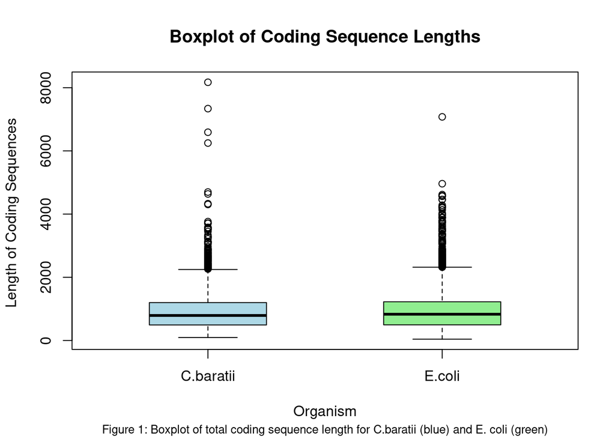

```r
# Combine lengths into a single data frame for boxplot
lengths_data <- data.frame(
  Length = c(len_ecoli, len_Cbaratii),
  Organism = factor(c(rep("E.coli", length(len_ecoli)), rep("C.baratii", length(len_Cbaratii))))
)

# Now create a boxplot
boxplot(Length ~ Organism, data = lengths_data,
        main = "Boxplot of Coding Sequence Lengths",
        xlab = "Organism",
        ylab = "Length of Coding Sequences ",
        col = c("lightblue", "lightgreen"),
        border = "black",
        boxwex = 0.5
        )

mtext("Figure 1: Boxplot of total coding sequence length for C.baratii (blue) and E. coli (green)", side = 1, line = 4, cex = 0.8)
```

From the boxplot, C. baratii has a lower median than E. coli. They have similar IQR, and both have many outliers. However C. baratii has outliers that are far higher.

### Question 4

We counted the nucleotide frequencies for both E. coli and C. baratii, stored them as numeric vectors, and visualized them with bar plots. Then, we translated the coding sequences into amino acids, calculated the frequency of each amino acid, and plotted the amino acid composition for both organisms in separate bar plots.

```r
count(unlist(cds_ecoli),1)
```

```
##
##       a       c       g       t
##  955768  977594 1088501  956665
```

```r
count(unlist(cds_Cbaratii),1)
```

```
##
##       a       c       g       t
## 1098189  283866  490344  826380
```

1. E. coli

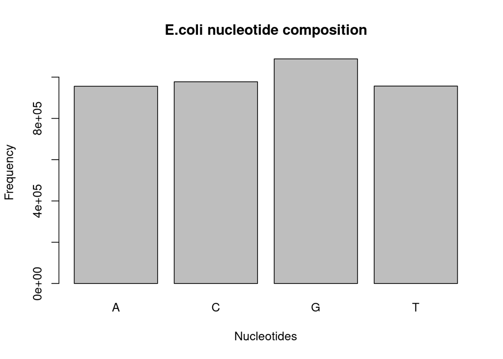

```r
#Unlist the entire E.coli sequence, then count each nucleotide and store
ecoli_dna_composition <- count(unlist(cds_ecoli),1)

# Bar plot of E.coli nucleotide frequency
barplot(ecoli_dna_composition,xlab="Nucleotides",ylab="Frequency", main="E.coli nucleotide composition", names.arg=toupper(names(ecoli_dna_composition)))
```

2. C. baratii

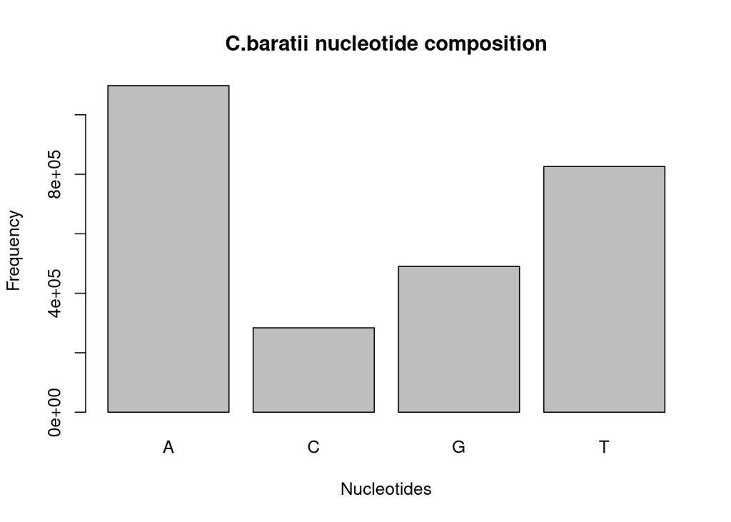

```r
#Unlist the entire C.baratii sequence, then count each nucleotide and store
cbaratii_dna_composition <- count(unlist(cds_Cbaratii),1)

#Bar plot of C.baratii nucleotide frequency
barplot(cbaratii_dna_composition,
        xlab="Nucleotides",
        ylab="Frequency",
        main="C.baratii nucleotide composition",
        names.arg=toupper(names(ecoli_dna_composition)))
```

From the barplots we can see that, E. coli has relatively balanced nucleotides (Adenine, Guanine, Cytosine and Thymine) with a slight bias towards Guanine. C. baratii is skewed towards nucleotide Adenine and Thymine, with lower counts of Cytosine and Guanine.

We then translate to amino acids

```r
 #Translate the sequences to aminoacids
prot_ecoli <- lapply(cds_ecoli,translate)
prot_cbaratii <- lapply(cds_Cbaratii,translate)
```

E. coli

```r
# Combine all protein sequences into a single vector
prot_ecoli_all<- unlist(prot_ecoli)

# Define the alphabet as the unique amino acids found in the proteins
aa1 <- unique(prot_ecoli_all[prot_ecoli_all != "*"])

# Count occurrences of each amino acid in the combined sequence
amino_acid_counts_ecoli <- count(prot_ecoli_all, wordsize = 1, alphabet = aa1)
```

Now create a Barplot of Ecoli

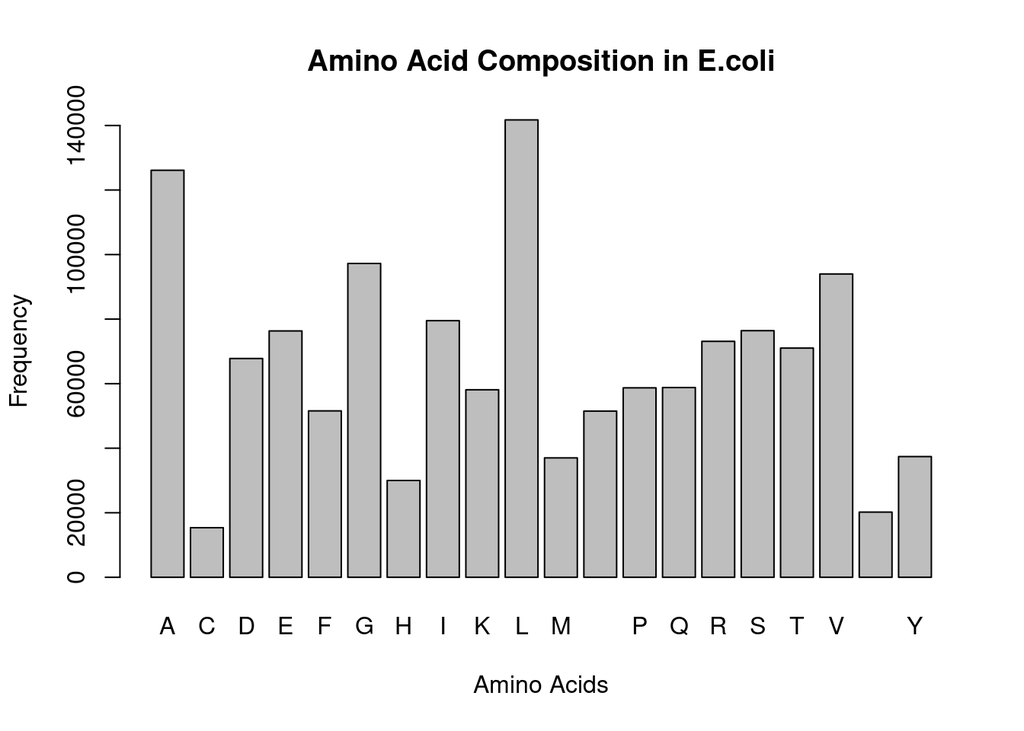

```r
# barplot of E.coli for amino acid frequency
barplot(amino_acid_counts_ecoli,
        xlab = "Amino Acids",
        ylab = "Frequency",
        main = "Amino Acid Composition in E.coli")
```

C. baratii

```r
# Combine all protein sequences into a single vector
prot_cbaratii_all<- unlist(prot_cbaratii)

# Define the alphabet as the unique amino acids found in the proteins
aa2 <- unique(prot_cbaratii_all[prot_cbaratii_all != "*"])

# Count occurrences of each amino acid in the combined sequence
amino_acid_counts_cbaratii <- count(prot_cbaratii_all, wordsize = 1, alphabet = aa2)
```

Now create a barplot for C. baratii

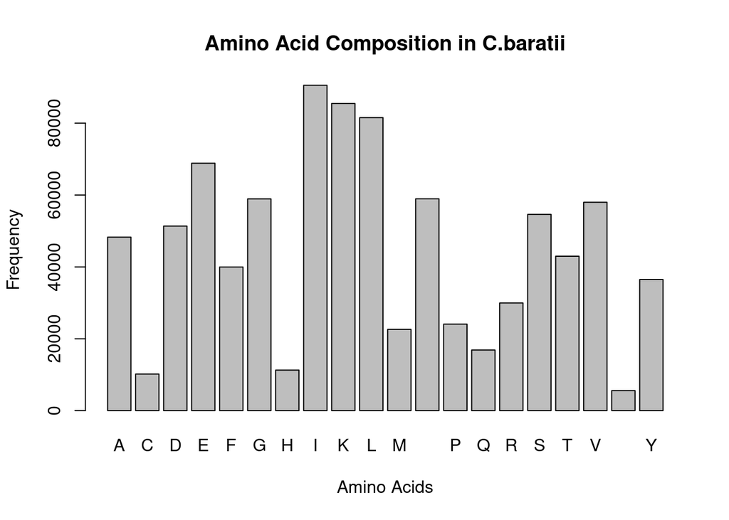

```r
# barplot of C.baratii for amino acid frequency
barplot(amino_acid_counts_cbaratii,
        xlab = "Amino Acids",
        ylab = "Frequency",
        main = "Amino Acid Composition in C.baratii")
```

From the barplots we can see that, the amino acid compositions of E. coli and C. baratii is relatively similar. However, E. coli uses Alanine, Leucine and Glycine the most, whereas C. baratii uses Isoleucine, lysine and Leucine the most.

### Question 5

We used UCO to calculate RSCU values for codons, formatted as a dataframe, added an organism column, and combined datasets for plotting. The data was split into two groups for clearer plots.

```r
# Creating the codon usage tables
# Finds all unique codons and their RSCU and puts them into a variable
ecoli_codon_bias <- uco(unlist(cds_ecoli[]), index="rscu", as.data.frame=TRUE)
cbaratii_codon_bias <- uco(unlist(cds_Cbaratii[]), index="rscu", as.data.frame=TRUE)

ecoli_codon_bias
```

```
##      AA codon   eff         freq      RSCU
## aaa Lys   aaa 44592 0.0336244963 1.5346652
## aac Asn   aac 28454 0.0214556741 1.1049453
## aag Lys   aag 13521 0.0101954793 0.4653348
## aat Asn   aat 23049 0.0173800461 0.8950547
## aca Thr   aca  9116 0.0068738991 0.5133967
## acc Thr   acc 31139 0.0234802922 1.7536924
## acg Thr   acg 19081 0.0143879847 1.0746075
## act Thr   act 11689 0.0088140639 0.6583034
## aga Arg   aga  2573 0.0019401648 0.2111584
## agc Ser   agc 21291 0.0160544302 1.6718055
## agg Arg   agg  1420 0.0010707478 0.1165351
## agt Ser   agt 11487 0.0086617463 0.9019787
## ata Ile   ata  5486 0.0041367058 0.2069902
## atc Ile   atc 33524 0.0252786960 1.2648816
## atg Met   atg 37007 0.0279050443 1.0000000
## att Ile   att 40501 0.0305396870 1.5281282
## caa Gln   caa 20402 0.0153840818 0.6939574
## cac His   cac 12890 0.0097196752 0.8594766
## cag Gln   cag 38397 0.0289531706 1.3060426
## cat His   cat 17105 0.0128979864 1.1405234
## cca Pro   cca 11163 0.0084174348 0.7606814
## ccc Pro   ccc  7238 0.0054577975 0.4932198
## ccg Pro   ccg 31074 0.0234312791 2.1174787
## cct Pro   cct  9225 0.0069560903 0.6286201
## cga Arg   cga  4619 0.0034829465 0.3790674
## cgc Arg   cgc 29441 0.0221999192 2.4161344
## cgg Arg   cgg  7079 0.0053379039 0.5809523
## cgt Arg   cgt 27979 0.0210975014 2.2961524
## cta Leu   cta  5149 0.0038825918 0.2179763
## ctc Leu   ctc 14811 0.0111682009 0.6270047
## ctg Leu   ctg 70714 0.0533217311 2.9935864
## ctt Leu   ctt 14586 0.0109985402 0.6174796
## gaa Glu   gaa 52679 0.0397224803 1.3801514
## gac Asp   gac 25347 0.0191128478 0.7477432
## gag Glu   gag 23659 0.0178400152 0.6198486
## gat Asp   gat 42449 0.0320085720 1.2522568
## gca Ala   gca 26743 0.0201654984 0.8481293
## gcc Ala   gcc 34117 0.0257258463 1.0819888
## gcg Ala   gcg 45082 0.0339939797 1.4297335
```

[output cut: 10 more lines]

```
## tac Tyr   tac 16160 0.0121854113 0.8641480
## tag Stp   tag   294 0.0002216900 0.2080679
## tat Tyr   tat 21241 0.0160167278 1.1358520
## tca Ser   tca  9303 0.0070149060 0.7304874
## tcc Ser   tcc 11390 0.0085886036 0.8943621
## tcg Ser   tcg 11830 0.0089203846 0.9289117
## tct Ser   tct 11111 0.0083782243 0.8724546
## tga Stp   tga  1219 0.0009191842 0.8627035
## tgc Cys   tgc  8574 0.0064652052 1.1152445
## tgg Trp   tgg 20196 0.0152287479 1.0000000
## tgt Cys   tgt  6802 0.0051290326 0.8847555
## tta Leu   tta 18323 0.0138164165 0.7756807
## ttc Phe   ttc 21974 0.0165694448 0.8523496
## ttg Leu   ttg 18148 0.0136844582 0.7682723
## ttt Phe   ttt 29587 0.0223100101 1.1476504
```

```r
cbaratii_codon_bias
```

```
##      AA codon   eff         freq        RSCU
## aaa Lys   aaa 63237 7.029512e-02 1.479591479
## aac Asn   aac  9373 1.041916e-02 0.318014488
## aag Lys   aag 22242 2.472451e-02 0.520408521
## aat Asn   aat 49574 5.510714e-02 1.681985512
## aca Thr   aca 21296 2.367293e-02 1.981668450
## acc Thr   acc  1014 1.127176e-03 0.094356302
## acg Thr   acg  1187 1.319486e-03 0.110454567
## act Thr   act 19489 2.166424e-02 1.813520681
## aga Arg   aga 25660 2.852401e-02 5.136622961
## agc Ser   agc  4225 4.696568e-03 0.464064731
## agg Arg   agg  2603 2.893531e-03 0.521068962
## agt Ser   agt 16241 1.805372e-02 1.783875810
## ata Ile   ata 54207 6.025725e-02 1.796004241
## atc Ile   atc  3947 4.387540e-03 0.130773309
## atg Met   atg 22625 2.515026e-02 1.000000000
## att Ile   att 32392 3.600739e-02 1.073222450
## caa Gln   caa 15230 1.692988e-02 1.805037037
## cac His   cac  2181 2.424430e-03 0.386359610
## cag Gln   cag  1645 1.828605e-03 0.194962963
## cat His   cat  9109 1.012569e-02 1.613640390
## cca Pro   cca 14683 1.632183e-02 2.438631457
## ccc Pro   ccc   267 2.968009e-04 0.044344793
## ccg Pro   ccg   708 7.870226e-04 0.117588440
## cct Pro   cct  8426 9.366458e-03 1.399435310
## cga Arg   cga   305 3.390422e-04 0.061054949
## cgc Arg   cgc    98 1.089382e-04 0.019617656
## cgg Arg   cgg    19 2.112066e-05 0.003803423
## cgt Arg   cgt  1288 1.431759e-03 0.257832049
## cta Leu   cta  7667 8.522743e-03 0.564171746
## ctc Leu   ctc   414 4.602081e-04 0.030463950
## ctg Leu   ctg   522 5.802624e-04 0.038411067
## ctt Leu   ctt 20954 2.329276e-02 1.541887931
## gaa Glu   gaa 58367 6.488156e-02 1.695310571
## gac Asp   gac  6208 6.900899e-03 0.241725722
## gag Glu   gag 10490 1.166083e-02 0.304689429
## gat Asp   gat 45156 5.019603e-02 1.758274278
## gca Ala   gca 24883 2.766029e-02 2.060917279
## gcc Ala   gcc  1774 1.972003e-03 0.146930324
## gcg Ala   gcg  1569 1.744122e-03 0.129951341
```

[output cut: 10 more lines]

```
## tac Tyr   tac  6087 6.766393e-03 0.333534247
## tag Stp   tag   606 6.736380e-04 0.620266121
## tat Tyr   tat 30413 3.380751e-02 1.666465753
## tca Ser   tca 20988 2.333055e-02 2.305275876
## tcc Ser   tcc   963 1.070484e-03 0.105773807
## tcg Ser   tcg   508 5.646998e-04 0.055797606
## tct Ser   tct 11701 1.300699e-02 1.285212170
## tga Stp   tga   110 1.222775e-04 0.112589560
## tgc Cys   tgc  2087 2.319938e-03 0.409336079
## tgg Trp   tgg  5581 6.203917e-03 1.000000000
## tgt Cys   tgt  8110 9.015188e-03 1.590663921
## tta Leu   tta 49366 5.487593e-02 3.632568464
## ttc Phe   ttc  8102 9.006295e-03 0.405322928
## ttg Leu   ttg  2616 2.907982e-03 0.192496842
## ttt Phe   ttt 31876 3.543380e-02 1.594677072
```

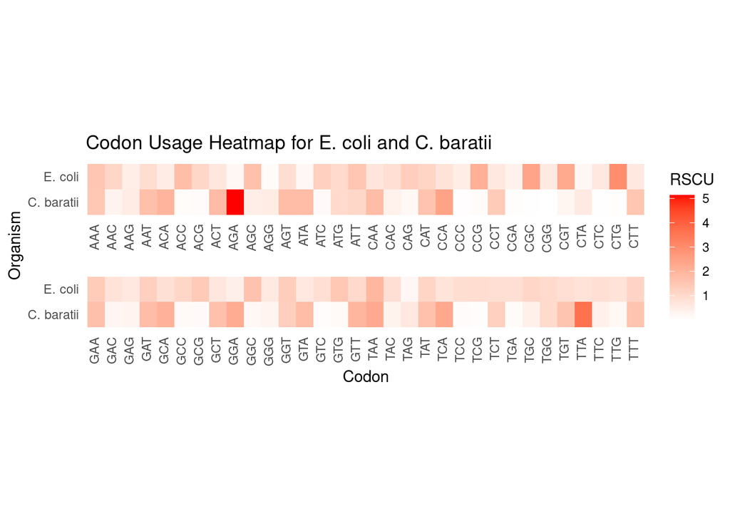

```r
# Creating the useful charts for data analysis

# Add new column called Organism and assign respective organism
ecoli_codon_bias$Organism <- "E. coli"
cbaratii_codon_bias$Organism <- "C. baratii"

# Combining the two data sets for plotting
combined_codon_bias <- rbind(ecoli_codon_bias, cbaratii_codon_bias)

# Ensuring column names are correct
colnames(combined_codon_bias) <- c("codon", "AA", "eff", "freq", "RSCU", "Organism")

# Format for the heatmap
heatmap_data <- combined_codon_bias[, c("AA", "Organism", "RSCU")]
heatmap_data$CodonGroup <- ifelse(as.numeric(factor(heatmap_data$AA)) <= 32, "First 32 Codons", "Second 32 Codons")

# Create the heatmap
ggplot(heatmap_data, aes(x = toupper(AA), y = Organism, fill = RSCU)) +
  geom_tile() +
  scale_fill_gradient(low="white", high="red", name = "RSCU") +
  labs(title = "Codon Usage Heatmap for E. coli and C. baratii",
       x = "Codon",
       y = "Organism") +
  theme_minimal() +
  theme(
    axis.text.x = element_text(angle = 90, vjust = 0.3, hjust = 1),
    panel.grid.major = element_blank(),
    panel.grid.minor = element_blank(),
    strip.text = element_blank(),
    aspect.ratio = 0.1,
    panel.spacing = unit(1, "lines")
  ) +
  facet_wrap(~ CodonGroup, nrow = 2, scales = "free_x") #Turns it into 2 graphs
```

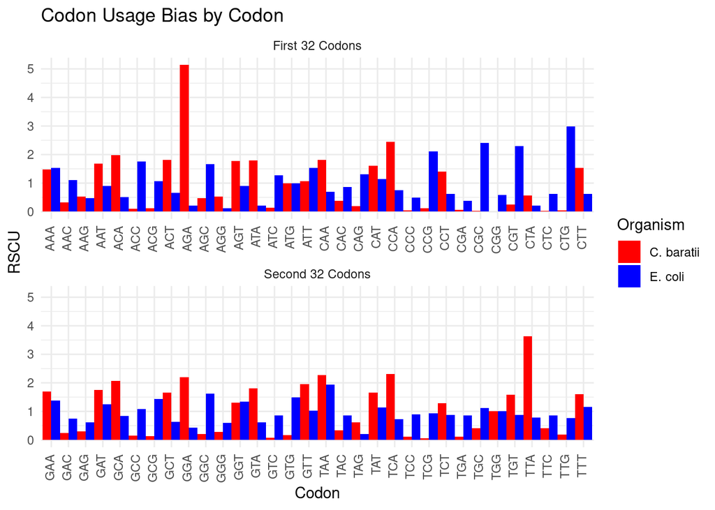

```r
# Create a Barchart
ggplot(heatmap_data, aes(x = toupper(AA), y = RSCU, fill = Organism)) + # "toupper" upper-cases the codons
  geom_bar(stat = "identity", position = "dodge",width = 1) +
  scale_fill_manual(values = c("E. coli" = "blue", "C. baratii" = "red")) +
  labs(title = "Codon Usage Bias by Codon", x = "Codon", y = "RSCU") +
  theme_minimal() +
  theme(axis.text.x = element_text(angle = 90, vjust=0.3, hjust = 1)) +
  facet_wrap(~ CodonGroup, nrow = 2, scales = "free_x") # Turns it into 2 graphs
```

From the heatmap and the barchart, we see that there are very large differences in Codon usage. E.coli expresses basically every codon, whereas C. baratii expresses little or none for certain codons such as CGG. C. baratii also has a preference for codon AGA

### Question 6

We used count with freq=TRUE to get k-mer (lengths 3-5) frequencies, sorted them, created data tables, and plotted barplots using ggplot. Smaller frequencies were adjusted for better visualization (Length 3 and 4)

```r
# Creating the length 3,4 and 5 K-mers for E.coli and C.baratii
freq_ecoli_3 <- count(prot_ecoli_all,wordsize=3,alphabet=aa1,freq=TRUE) # Count the frequency for k-mers length 3
freq_ecoli_4 <- count(prot_ecoli_all,wordsize=4,alphabet=aa1,freq=TRUE) # Count the frequency for k-mers length 4
freq_ecoli_5 <- count(prot_ecoli_all,wordsize=5,alphabet=aa1,freq=TRUE) # Count the frequency for k-mers length 5

freq_cbaratii_3 <- count(prot_cbaratii_all,wordsize=3,alphabet=aa2,freq=TRUE) # Count the frequency for k-mers length 3
freq_cbaratii_4 <- count(prot_cbaratii_all,wordsize=4,alphabet=aa2,freq=TRUE) # Count the frequency for k-mers length 4
freq_cbaratii_5 <- count(prot_cbaratii_all,wordsize=5,alphabet=aa2,freq=TRUE) # Count the frequency for k-mers length 5
```

```r
# Sorting the K-mers by frequency for C.baratii
top_overrepresented_cbaratii_3 <- head(sort(freq_cbaratii_3, decreasing = TRUE), 10) # Sort the frequencies in decreasing order, take the top 10

bottom_underrepresented_cbaratii_3 <- head(sort(freq_cbaratii_3), 10) # Sort the frequencies in increasing order, take the top 10

print(top_overrepresented_cbaratii_3)
```

```
##
##          LKE          IKE          KEL          KEI          KEK          KKI
## 0.0013235294 0.0012438258 0.0011775932 0.0011158509 0.0010148181 0.0010024697
##          LKK          KNI          KKL          KEE
## 0.0009934890 0.0009811405 0.0009788954 0.0009598114
```

```r
print(bottom_underrepresented_cbaratii_3)
```

```
##
## CCW CLW CWM CWQ CWT CWV ECW FCW HHW HQW
##   0   0   0   0   0   0   0   0   0   0
```

```r
top_overrepresented_cbaratii_4 <- head(sort(freq_cbaratii_4, decreasing = TRUE), 10) # Sort the frequencies in decreasing order, take the top 10

bottom_underrepresented_cbaratii_4 <- head(sort(freq_cbaratii_4), 10) # Sort the frequencies in increasing order, take the top 10

print(top_overrepresented_cbaratii_4)
```

```
##
##         KLKE         LKEL         LKEK         EELK         KIKE         IKEI
## 0.0001678175 0.0001588072 0.0001486706 0.0001441654 0.0001441654 0.0001430391
##         EKIK         GATG         IKNI         EEIK
## 0.0001396602 0.0001340288 0.0001340288 0.0001317762
```

```r
print(bottom_underrepresented_cbaratii_4)
```

```
##
## AACC AACD AACQ AACW AADW AAGH AAHF AAHM AAHQ AAKH
##    0    0    0    0    0    0    0    0    0    0
```

```r
top_overrepresented_cbaratii_5 <- head(sort(freq_cbaratii_5, decreasing = TRUE), 10) # Sort the frequencies in decreasing order, take the top 10

bottom_underrepresented_cbaratii_5 <- head(sort(freq_cbaratii_5), 10) # Sort the frequencies in increasing order, take the top 10

print(top_overrepresented_cbaratii_5)
```

```
##
##        TGATG        GATGA        GPEGP        GPTGA        ATGAT        TGPTG
## 8.362168e-05 5.989120e-05 5.424109e-05 4.407088e-05 4.181084e-05 3.842077e-05
##        PTGAT        EKLKE        LSGGQ        EELKK
## 3.729075e-05 3.277066e-05 3.277066e-05 3.164063e-05
```

```r
print(bottom_underrepresented_cbaratii_5)
```

```
##
## AAAAC AAAAD AAAAH AAAAL AAAAM AAAAW AAACC AAACD AAACE AAACF
##     0     0     0     0     0     0     0     0     0     0
```

```r
# Sorting the K-mers by frequency for E. coli
top_overrepresented_ecoli_3 <- head(sort(freq_ecoli_3, decreasing = TRUE), 10) # Sort the frequencies in decreasing order, take the top 10

bottom_underrepresented_ecoli_3 <- head(sort(freq_ecoli_3), 10) # Sort the frequencies in increasing order, take the top 10

print(top_overrepresented_ecoli_3)
```

```
##
##          LLA          ALL          ALA          LAA          AAL          LLL
## 0.0013833702 0.0013277917 0.0013247463 0.0012189189 0.0012135895 0.0012135895
##          LAL          AAA          LAG          TLL
## 0.0011694312 0.0010186843 0.0008968685 0.0008390060
```

```r
print(bottom_underrepresented_ecoli_3)
```

```
##
##          CMY          MWC          WMC          CMC          CMW          WCM
## 7.613485e-07 7.613485e-07 7.613485e-07 1.522697e-06 1.522697e-06 1.522697e-06
##          WWC          CHW          CWW          MCM
## 1.522697e-06 2.284045e-06 2.284045e-06 2.284045e-06
```

```r
top_overrepresented_ecoli_4 <- head(sort(freq_ecoli_4, decreasing = TRUE), 10) # Sort the frequencies in decreasing order, take the top 10

bottom_underrepresented_ecoli_4 <- head(sort(freq_ecoli_4), 10) # Sort the frequencies in increasing order, take the top 10

print(top_overrepresented_ecoli_4)
```

```
##
##         LAAL         ALAA         LLAL         LLLL         AALA         LLAA
## 0.0001787324 0.0001779686 0.0001642199 0.0001596370 0.0001581094 0.0001573456
##         LLLA         LALA         LALL         ALLA
## 0.0001504713 0.0001497075 0.0001489436 0.0001474160
```

```r
print(bottom_underrepresented_ecoli_4)
```

```
##
## ACAM ACCF ACCH ACCI ACCK ACCM ACCQ ACCW ACEW ACFP
##    0    0    0    0    0    0    0    0    0    0
```

```r
top_overrepresented_ecoli_5 <- head(sort(freq_ecoli_5, decreasing = TRUE), 10) # Sort the frequencies in decreasing order, take the top 10

bottom_underrepresented_ecoli_5 <- head(sort(freq_ecoli_5), 10) # Sort the frequencies in increasing order, take the top 10

print(top_overrepresented_ecoli_5)
```

```
##
##        GKSTL        GSGKS        AALAA        LLAAL        SGSGK        LLLDE
## 4.444509e-05 3.218438e-05 2.835290e-05 2.835290e-05 2.835290e-05 2.682031e-05
##        LAAAL        LLLAL        LLLLL        LDEPT
## 2.605402e-05 2.605402e-05 2.605402e-05 2.528772e-05
```

```r
print(bottom_underrepresented_ecoli_5)
```

```
##
## AAAAC AAAAW AAACC AAACH AAACI AAACK AAACM AAACN AAACP AAACS
##     0     0     0     0     0     0     0     0     0     0
```

Creating the data for plotting

```r
# Data for E. coli length 3
ecoli_kmer_3 <- data.frame(
  kmer = names(c(top_overrepresented_ecoli_3, bottom_underrepresented_ecoli_3)),
  frequency = c(top_overrepresented_ecoli_3, bottom_underrepresented_ecoli_3),
  type = c(rep("Overrepresented", 10), rep("Underrepresented", 10)),
  Organism = "E. coli",
  Length = 3
)

# Data for E. coli length 4
ecoli_kmer_4 <- data.frame(
  kmer = names(c(top_overrepresented_ecoli_4, bottom_underrepresented_ecoli_4)),
  frequency = c(top_overrepresented_ecoli_4, bottom_underrepresented_ecoli_4),
  type = c(rep("Overrepresented", 10), rep("Underrepresented", 10)),
  Organism = "E. coli",
  Length = 4
)

# Data for E. coli length 5
ecoli_kmer_5 <- data.frame(
  kmer = names(c(top_overrepresented_ecoli_5, bottom_underrepresented_ecoli_5)),
  frequency = c(top_overrepresented_ecoli_5, bottom_underrepresented_ecoli_5),
  type = c(rep("Overrepresented", 10), rep("Underrepresented", 10)),
  Organism = "E. coli",
  Length = 5
)

# Now do the same for C. baratii
# Data for C. baratii length 3
cbaratii_kmer_3 <- data.frame(
  kmer = names(c(top_overrepresented_cbaratii_3, bottom_underrepresented_cbaratii_3)),
  frequency = c(top_overrepresented_cbaratii_3, bottom_underrepresented_cbaratii_3),
  type = c(rep("Overrepresented", 10), rep("Underrepresented", 10)),
  Organism = "C. baratii",
  Length = 3
)

# Data for C. baratii length 4
cbaratii_kmer_4 <- data.frame(
  kmer = names(c(top_overrepresented_cbaratii_4, bottom_underrepresented_cbaratii_4)),
  frequency = c(top_overrepresented_cbaratii_4, bottom_underrepresented_cbaratii_4),
  type = c(rep("Overrepresented", 10), rep("Underrepresented", 10)),
  Organism = "C. baratii",
  Length = 4
)

# Data for C. baratii length 5
cbaratii_kmer_5 <- data.frame(
  kmer = names(c(top_overrepresented_cbaratii_5, bottom_underrepresented_cbaratii_5)),
  frequency = c(top_overrepresented_cbaratii_5, bottom_underrepresented_cbaratii_5),
  type = c(rep("Overrepresented", 10), rep("Underrepresented", 10)),
  Organism = "C. baratii",
  Length = 5
)
```

Plot adjusted frequency for Length 3 K-mers

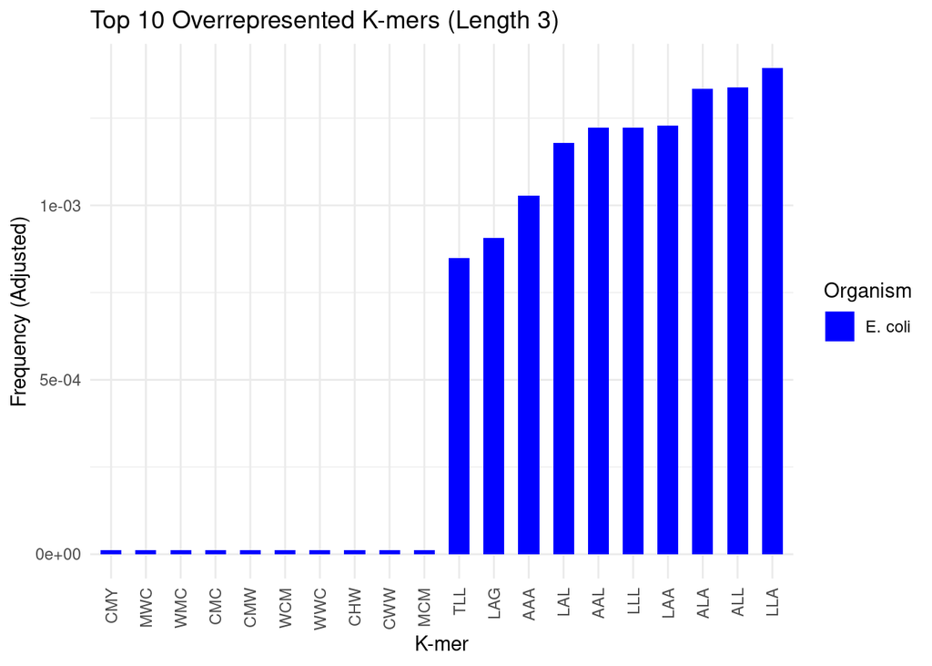

```r
# Add a small constant to all frequencies
ecoli_kmer_3$adjusted_frequency <- ecoli_kmer_3$frequency + 0.00001 # Because the bottom 10 look like 0 but are not

ggplot(ecoli_kmer_3, aes(x = reorder(kmer, adjusted_frequency), y = adjusted_frequency, fill = Organism)) +
  geom_bar(stat = "identity", position = "dodge", width = 0.6) +
  labs(title = "Top 10 Overrepresented K-mers (Length 3)",
       x = "K-mer",
       y = "Frequency (Adjusted)") +
  scale_fill_manual(values = c("E. coli" = "blue", "C. baratii" = "red")) +
  theme_minimal() +
  theme(axis.text.x = element_text(angle = 90, vjust = 0.5, hjust = 1))
```

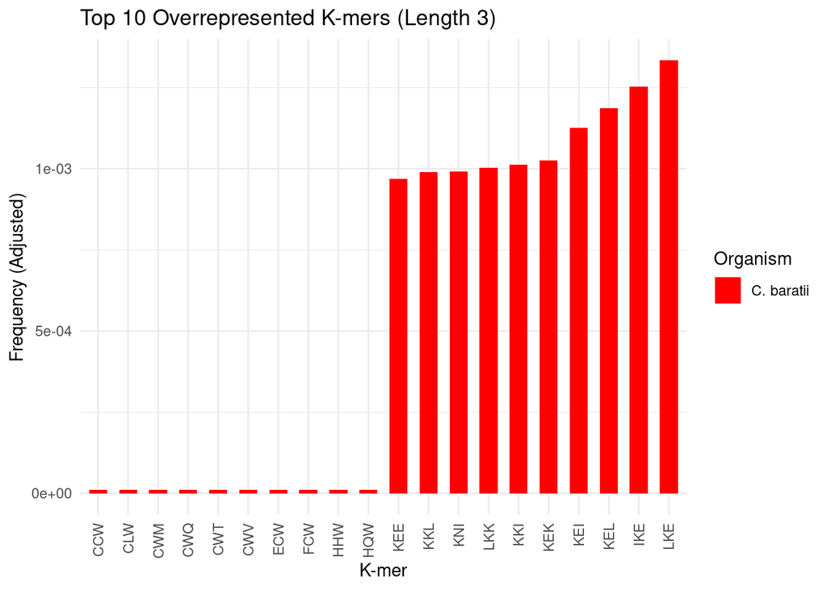

```r
cbaratii_kmer_3$adjusted_frequency <- cbaratii_kmer_3$frequency + 0.00001 # Because the bottom 10 look like 0 but are not

ggplot(cbaratii_kmer_3, aes(x = reorder(kmer, adjusted_frequency), y = adjusted_frequency, fill = Organism)) +
  geom_bar(stat = "identity", position = "dodge", width = 0.6) +
  labs(title = "Top 10 Overrepresented K-mers (Length 3)",
       x = "K-mer",
       y = "Frequency (Adjusted)") +
  scale_fill_manual(values = c("E. coli" = "blue", "C. baratii" = "red")) +
  theme_minimal() +
  theme(axis.text.x = element_text(angle = 90, vjust = 0.5, hjust = 1))
```

Plot adjusted frequency for Length 4 K-mers

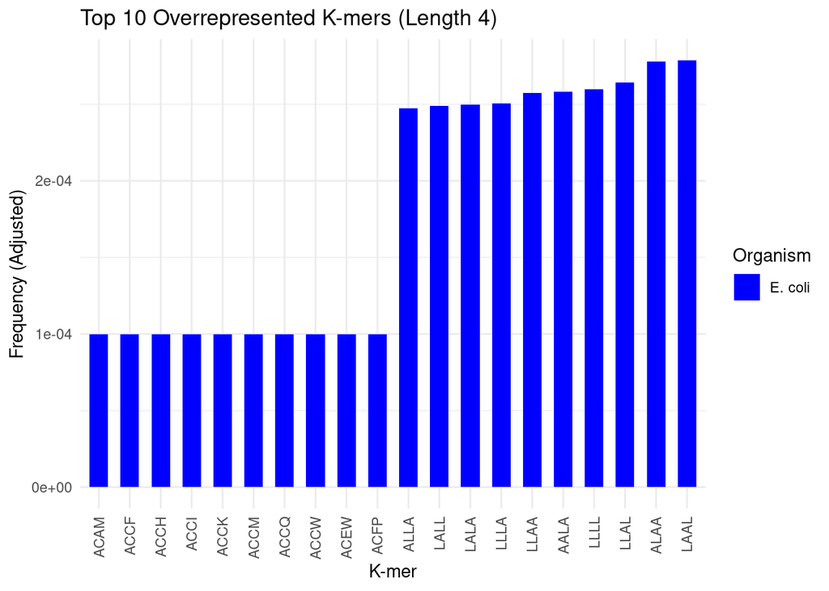

```r
# Add a small constant to all frequencies
ecoli_kmer_4$adjusted_frequency <- ecoli_kmer_4$frequency + 0.0001

ggplot(ecoli_kmer_4, aes(x = reorder(kmer, adjusted_frequency), y = adjusted_frequency, fill = Organism)) +
  geom_bar(stat = "identity", position = "dodge", width = 0.6) +
  labs(title = "Top 10 Overrepresented K-mers (Length 4)",
       x = "K-mer",
       y = "Frequency (Adjusted)") +
  scale_fill_manual(values = c("E. coli" = "blue", "C. baratii" = "red")) +
  theme_minimal() +
  theme(axis.text.x = element_text(angle = 90, vjust = 0.5, hjust = 1))
```

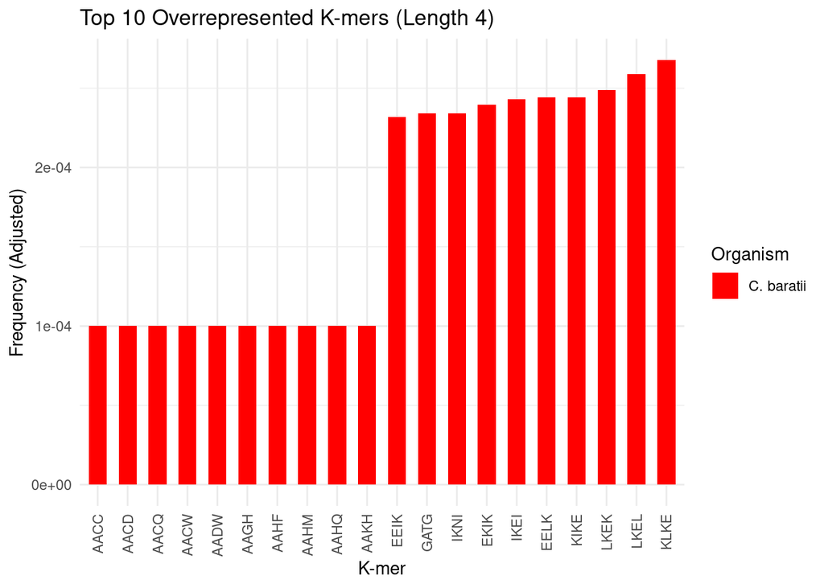

```r
cbaratii_kmer_4$adjusted_frequency <- cbaratii_kmer_4$frequency + 0.0001

ggplot(cbaratii_kmer_4, aes(x = reorder(kmer, adjusted_frequency), y = adjusted_frequency, fill = Organism)) +
  geom_bar(stat = "identity", position = "dodge", width = 0.6) +
  labs(title = "Top 10 Overrepresented K-mers (Length 4)",
       x = "K-mer",
       y = "Frequency (Adjusted)") +
  scale_fill_manual(values = c("E. coli" = "blue", "C. baratii" = "red")) +
  theme_minimal() +
  theme(axis.text.x = element_text(angle = 90, vjust = 0.5, hjust = 1))
```

Plot unadjusted graphs for length 5 k-mers

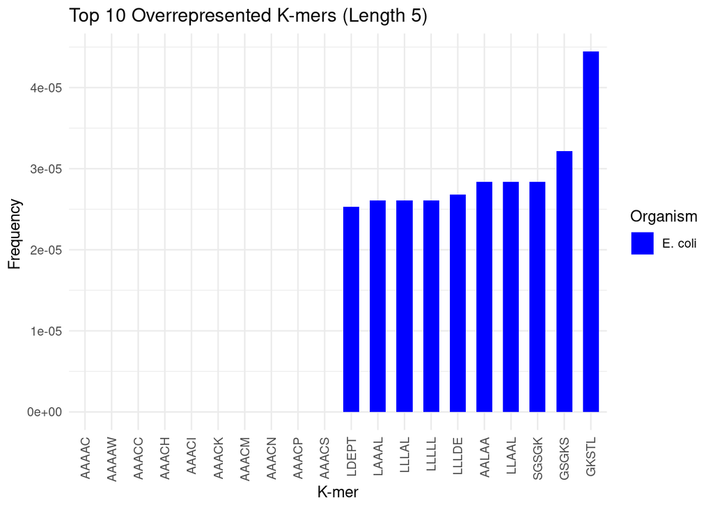

```r
# Add a small constant to all frequencies
ecoli_kmer_5$adjusted_frequency <- ecoli_kmer_5$frequency + 0 # We do not adjust the frequency here

ggplot(ecoli_kmer_5, aes(x = reorder(kmer, adjusted_frequency), y = adjusted_frequency, fill = Organism)) +
  geom_bar(stat = "identity", position = "dodge", width = 0.6) +
  labs(title = "Top 10 Overrepresented K-mers (Length 5)",
       x = "K-mer",
       y = "Frequency ") +
  scale_fill_manual(values = c("E. coli" = "blue", "C. baratii" = "red")) +
  theme_minimal() +
  theme(axis.text.x = element_text(angle = 90, vjust = 0.5, hjust = 1))
```

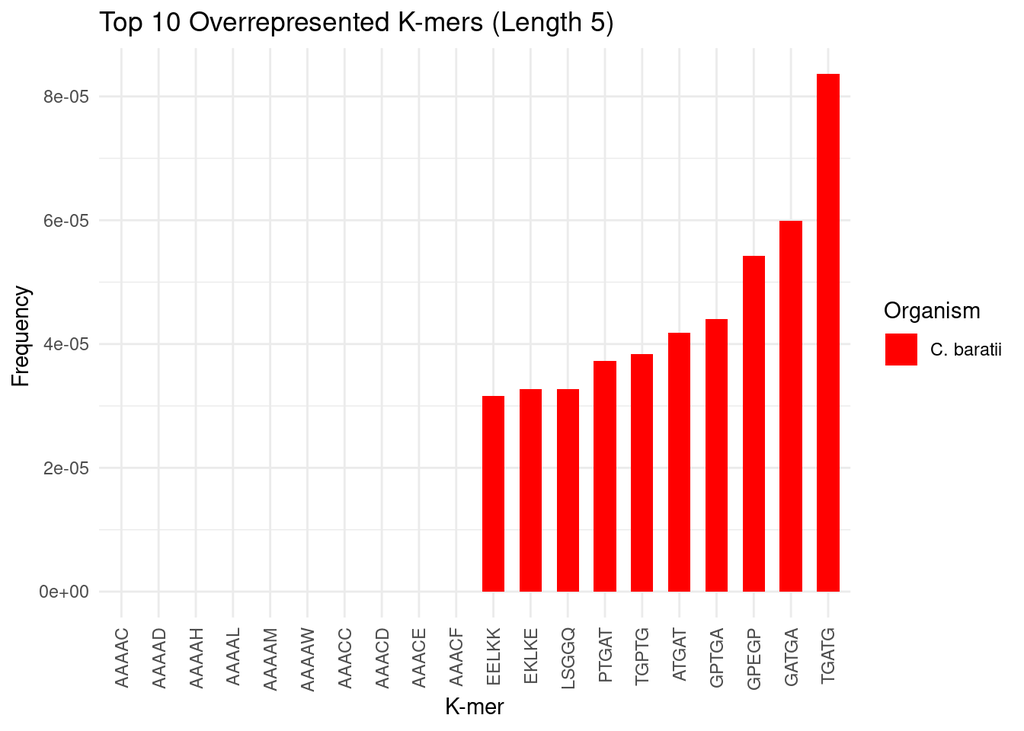

```r
cbaratii_kmer_5$adjusted_frequency <- cbaratii_kmer_5$frequency + 0 # We do not adjust the frequency here

ggplot(cbaratii_kmer_5, aes(x = reorder(kmer, adjusted_frequency), y = adjusted_frequency, fill = Organism)) +
  geom_bar(stat = "identity", position = "dodge", width = 0.6) +
  labs(title = "Top 10 Overrepresented K-mers (Length 5)",
       x = "K-mer",
       y = "Frequency ") +
  scale_fill_manual(values = c("E. coli" = "blue", "C. baratii" = "red")) +
  theme_minimal() +
  theme(axis.text.x = element_text(angle = 90, vjust = 0.5, hjust = 1))
```

From the plot, we see that the under-represented k-mers of length 3,4,5 are similar for both organisms. This may be because the aminoacids that it encodes for may not be necessary for bacteria to survive. However, the overrepresented k-mers for all lengths are different between E. coli and C. baratii, they are very different species, so need different expressions for different environments and tasks.